# Survival Analysis HW 3

Victor Feagins

10/1/2021

### Question 5.8

First 10 Observations of Melanoma Patients

| PATIENT | AGE | SEX | TYPE2A | TYPE3A | TYPE3B | TYPE4A | TREATMENT | REMTIME | RELAPSE | LIFETIME | DEATH |
| --- | --- | --- | --- | --- | --- | --- | --- | --- | --- | --- | --- |
| 1 | 59 | 0 | 0 | 0 | 1 | 0 | 1 | 33.7 | 0 | 33.7 | 0 |
| 2 | 50 | 0 | 0 | 0 | 1 | 0 | 1 | 3.8 | 1 | 3.9 | 1 |
| 3 | 76 | 1 | 0 | 0 | 1 | 0 | 1 | 6.3 | 1 | 10.5 | 1 |
| 4 | 66 | 0 | 0 | 0 | 1 | 0 | 1 | 2.3 | 1 | 5.4 | 1 |
| 5 | 33 | 1 | 0 | 0 | 1 | 0 | 1 | 6.4 | 1 | 19.5 | 1 |
| 6 | 23 | 0 | 0 | 0 | 1 | 0 | 1 | 23.8 | 0 | 23.8 | 0 |
| 7 | 40 | 0 | 0 | 0 | 1 | 0 | 1 | 1.8 | 1 | 7.9 | 1 |
| 8 | 34 | 1 | 0 | 0 | 1 | 0 | 1 | 5.5 | 1 | 16.9 | 0 |
| 9 | 34 | 1 | 0 | 0 | 1 | 0 | 1 | 16.6 | 0 | 16.6 | 0 |
| 10 | 38 | 0 | 1 | 0 | 0 | 0 | 1 | 33.7 | 0 | 33.7 | 0 |

#### Lifetime

In this problem we will be looking at lifetime of a patient comparing treatments.

```r
surv.data.5.8 <- Surv(df.5.8$LIFETIME, df.5.8$DEATH)
km.5.8 <- survfit(surv.data.5.8 ~ TREATMENT, data = df.5.8)
summary(km.5.8)
```

```
## Call: survfit(formula = surv.data.5.8 ~ TREATMENT, data = df.5.8)
##
##                 TREATMENT=1
##  time n.risk n.event survival std.err lower 95% CI upper 95% CI
##   3.9     11       1    0.909  0.0867        0.754        1.000
##   5.4     10       1    0.818  0.1163        0.619        1.000
##   7.9      9       1    0.727  0.1343        0.506        1.000
##  10.5      8       1    0.636  0.1450        0.407        0.995
##  19.5      4       1    0.477  0.1755        0.232        0.981
##
##                 TREATMENT=2
##  time n.risk n.event survival std.err lower 95% CI upper 95% CI
##   6.9     19       1    0.947  0.0512        0.852        1.000
##   7.7     18       1    0.895  0.0704        0.767        1.000
##   8.0     16       1    0.839  0.0854        0.687        1.000
##   8.3     13       1    0.774  0.1003        0.601        0.998
##  24.4      3       1    0.516  0.2211        0.223        1.000
```

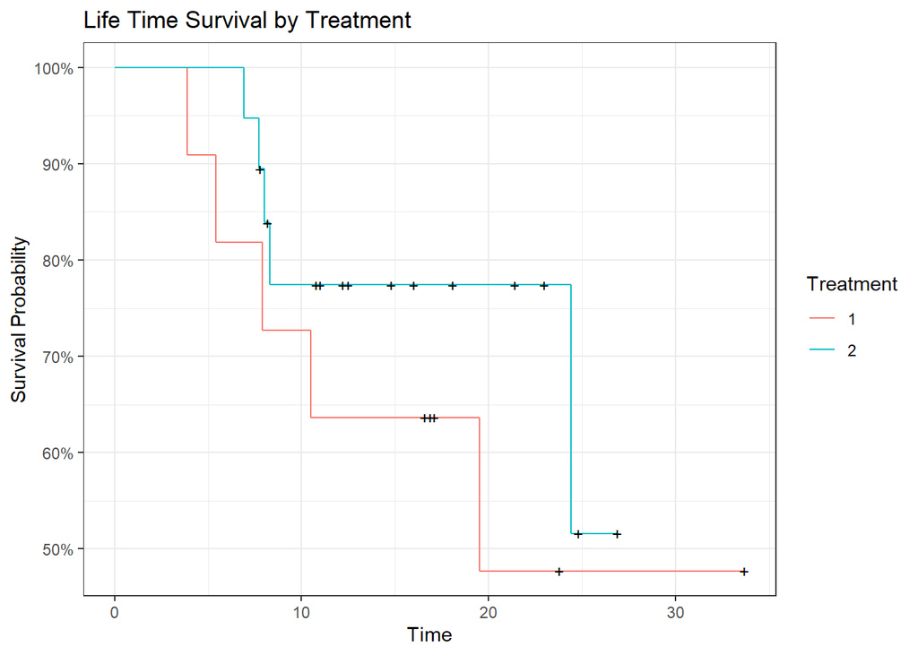

```r
autoplot(km.5.8, conf.int = F) +
  labs(title = "Life Time Survival by Treatment",
       x = "Time",
       y = "Survival Probability",
       colour = "Treatment")
```

Testing to see if the groups are different?

```r
survdiff(surv.data.5.8 ~ TREATMENT, data = df.5.8)
```

```
## Call:
## survdiff(formula = surv.data.5.8 ~ TREATMENT, data = df.5.8)
##
##              N Observed Expected (O-E)^2/E (O-E)^2/V
## TREATMENT=1 11        5     3.68     0.469     0.747
## TREATMENT=2 19        5     6.32     0.274     0.747
##
##  Chisq= 0.7  on 1 degrees of freedom, p= 0.4
```

When looking at the log rank test we have a p value of .4 which means we fail to reject the null that the two treatments result in different lifetime survival times.

#### Remission Time

We did not see a significant change in the lifetimes between treatments but perhaps we can see a difference in the remission times.

```r
surv.data.5.8 <- Surv(df.5.8$REMTIME, df.5.8$RELAPSE)
km.5.8 <- survfit(surv.data.5.8 ~ TREATMENT, data = df.5.8)
summary(km.5.8)
```

```
## Call: survfit(formula = surv.data.5.8 ~ TREATMENT, data = df.5.8)
##
##                 TREATMENT=1
##  time n.risk n.event survival std.err lower 95% CI upper 95% CI
##   1.8     11       1    0.909  0.0867        0.754        1.000
##   2.3     10       1    0.818  0.1163        0.619        1.000
##   3.8      9       1    0.727  0.1343        0.506        1.000
##   5.5      8       1    0.636  0.1450        0.407        0.995
##   6.3      7       1    0.545  0.1501        0.318        0.936
##   6.4      6       1    0.455  0.1501        0.238        0.868
##
##                 TREATMENT=2
##  time n.risk n.event survival std.err lower 95% CI upper 95% CI
##   2.8     19       1    0.947  0.0512        0.852        1.000
##   3.0     18       1    0.895  0.0704        0.767        1.000
##   4.3     17       1    0.842  0.0837        0.693        1.000
##   4.5     16       1    0.789  0.0935        0.626        0.996
##   5.8     15       1    0.737  0.1010        0.563        0.964
##   6.8     14       1    0.684  0.1066        0.504        0.929
##   9.2     10       2    0.547  0.1215        0.354        0.846
##  15.9      6       1    0.456  0.1311        0.260        0.801
##  22.1      3       1    0.304  0.1518        0.114        0.809
```

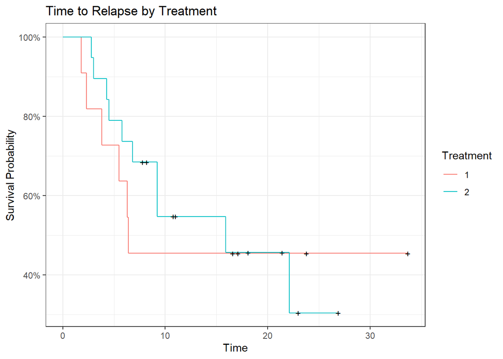

```r
autoplot(km.5.8, conf.int = F) +
  labs(title = "Time to Relapse by Treatment",
       x = "Time",
       y = "Survival Probability",
       colour = "Treatment")
```

```r
survdiff(surv.data.5.8 ~ TREATMENT, data = df.5.8)
```

```
## Call:
## survdiff(formula = surv.data.5.8 ~ TREATMENT, data = df.5.8)
##
##              N Observed Expected (O-E)^2/E (O-E)^2/V
## TREATMENT=1 11        6     5.55    0.0366    0.0573
## TREATMENT=2 19       10    10.45    0.0194    0.0573
##
##  Chisq= 0.1  on 1 degrees of freedom, p= 0.8
```

In time to relapse we also don’t see a significant difference in time to relapse with a p value of .8.

### Question 5.14

Sixty-six patients are separated into three treatment groups. The initial remission times are given in weeks. Are the three treatment groups equally effective in prolonging remission? Discuss your findings!

9 Observations of Remission Times

| treat | n | time | cens |
| --- | --- | --- | --- |
| 1 | 25 | 13 | 1 |
| 1 | 25 | 100 | 1 |
| 1 | 25 | 10 | 1 |
| 2 | 19 | 10 | 1 |
| 2 | 19 | 75 | 1 |
| 2 | 19 | 199 | 0 |
| 3 | 22 | 197 | 0 |
| 3 | 22 | 31 | 1 |
| 3 | 22 | 28 | 1 |

```r
surv.data.5.14 <- Surv(df.5.14$time, abs(df.5.14$cens))
km.5.14 <- survfit(surv.data.5.14 ~ treat, data = df.5.14)
summary(km.5.14)
```

```
## Call: survfit(formula = surv.data.5.14 ~ treat, data = df.5.14)
##
##                 treat=1
##  time n.risk n.event survival std.err lower 95% CI upper 95% CI
##     4     25       1   0.9600  0.0392       0.8862        1.000
##     5     24       1   0.9200  0.0543       0.8196        1.000
##     9     23       1   0.8800  0.0650       0.7614        1.000
##    10     22       2   0.8000  0.0800       0.6576        0.973
##    12     20       1   0.7600  0.0854       0.6097        0.947
##    13     19       1   0.7200  0.0898       0.5639        0.919
##    23     17       1   0.6776  0.0940       0.5164        0.889
##    28     16       3   0.5506  0.1010       0.3843        0.789
##    29     13       1   0.5082  0.1017       0.3433        0.752
##    31     12       1   0.4659  0.1017       0.3037        0.715
##    32     11       1   0.4235  0.1009       0.2655        0.676
```

[output cut: 39 more lines]

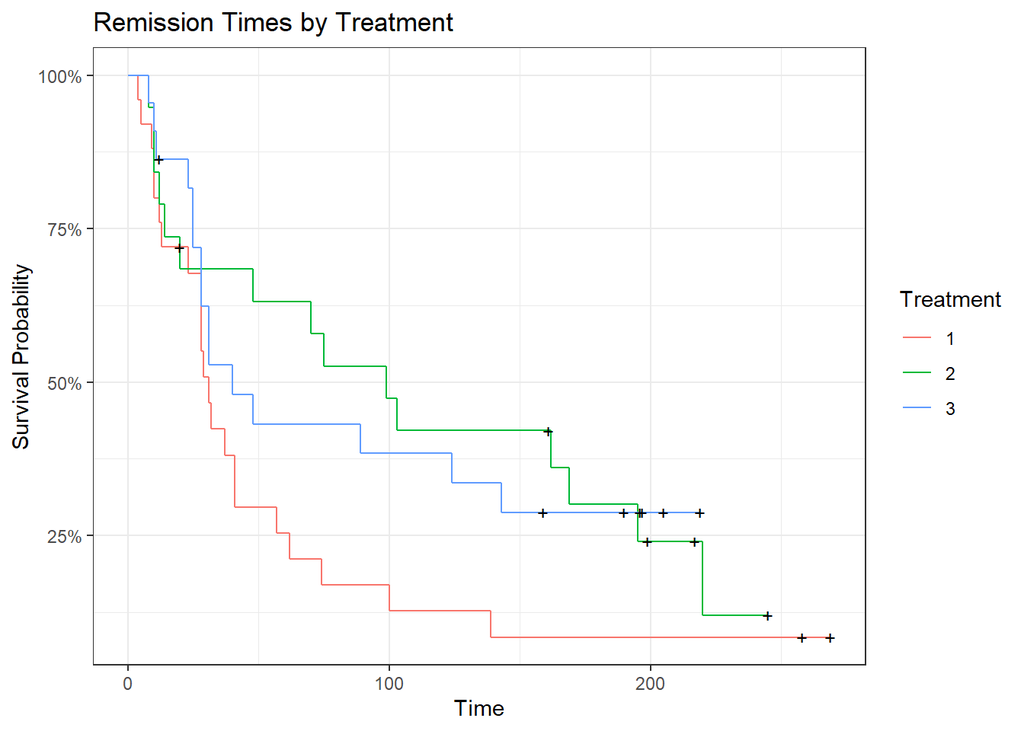

```r
autoplot(km.5.14, conf.int = F) +
  labs(title = "Remission Times by Treatment",
       x = "Time",
       y = "Survival Probability",
       colour = "Treatment")
```

```r
survdiff(surv.data.5.14 ~ treat, data = df.5.14)
```

```
## Call:
## survdiff(formula = surv.data.5.14 ~ treat, data = df.5.14)
##
##          N Observed Expected (O-E)^2/E (O-E)^2/V
## treat=1 25       22     15.4     2.865     4.335
## treat=2 19       15     18.7     0.730     1.195
## treat=3 22       15     17.9     0.482     0.764
##
##  Chisq= 4.3  on 2 degrees of freedom, p= 0.1
```

```r
survminer::pairwise_survdiff(Surv(time, cens) ~ treat, data = df.5.14, p.adjust.method = "bonferroni")
```

```
##
##  Pairwise comparisons using Log-Rank test
##
## data:  df.5.14 and treat
##
##   1    2
## 2 0.16 -
## 3 0.27 1.00
##
## P value adjustment method: bonferroni
```

When doing pairwise comparisons we see that treatment 1 is the most different which we could have inferred from the graph but none of the treatments are significantly different from each other. We will need more information in treatment 1 study to possibly arrive at statistical significance.

```r
survminer::pairwise_survdiff(Surv(time, cens) ~ treat, data = df.5.14, p.adjust.method = "none")
```

```
##
##  Pairwise comparisons using Log-Rank test
##
## data:  df.5.14 and treat
##
##   1     2
## 2 0.055 -
## 3 0.091 0.868
##
## P value adjustment method: none
```